# Project: Identify Customer Segments

In this project, you will apply unsupervised learning techniques to identify segments of the population that form the core customer base for a mail-order sales company in Germany. These segments can then be used to direct marketing campaigns towards audiences that will have the highest expected rate of returns. The data that you will use has been provided by our partners at Bertelsmann Arvato Analytics, and represents a real-life data science task.

This notebook will help you complete this task by providing a framework within which you will perform your analysis steps. In each step of the project, you will see some text describing the subtask that you will perform, followed by one or more code cells for you to complete your work. **Feel free to add additional code and markdown cells as you go along so that you can explore everything in precise chunks.** The code cells provided in the base template will outline only the major tasks, and will usually not be enough to cover all of the minor tasks that comprise it.

It should be noted that while there will be precise guidelines on how you should handle certain tasks in the project, there will also be places where an exact specification is not provided. **There will be times in the project where you will need to make and justify your own decisions on how to treat the data.** These are places where there may not be only one way to handle the data. In real-life tasks, there may be many valid ways to approach an analysis task. One of the most important things you can do is clearly document your approach so that other scientists can understand the decisions you've made.

At the end of most sections, there will be a Markdown cell labeled **Discussion**. In these cells, you will report your findings for the completed section, as well as document the decisions that you made in your approach to each subtask. **Your project will be evaluated not just on the code used to complete the tasks outlined, but also your communication about your observations and conclusions at each stage.**

```python
# import libraries here; add more as necessary
import numpy as np
import pandas as pd
import matplotlib.pyplot as plt
import seaborn as sns
import sklearn
# magic word for producing visualizations in notebook
%matplotlib inline

'''
Import note: The classroom currently uses sklearn version 0.19.
If you need to use an imputer, it is available in sklearn.preprocessing.Imputer,
instead of sklearn.impute as in newer versions of sklearn.
'''
```

```
'\nImport note: The classroom currently uses sklearn version 0.19.\nIf you need to use an imputer, it is available in sklearn.preprocessing.Imputer,\ninstead of sklearn.impute as in newer versions of sklearn.\n'
```

### Step 0: Load the Data

There are four files associated with this project (not including this one):

Each row of the demographics files represents a single person, but also includes information outside of individuals, including information about their household, building, and neighborhood. You will use this information to cluster the general population into groups with similar demographic properties. Then, you will see how the people in the customers dataset fit into those created clusters. The hope here is that certain clusters are over-represented in the customers data, as compared to the general population; those over-represented clusters will be assumed to be part of the core userbase. This information can then be used for further applications, such as targeting for a marketing campaign.

To start off with, load in the demographics data for the general population into a pandas DataFrame, and do the same for the feature attributes summary. Note for all of the `.csv` data files in this project: they're semicolon (`;`) delimited, so you'll need an additional argument in your [`read_csv()`](https://pandas.pydata.org/pandas-docs/stable/generated/pandas.read_csv.html) call to read in the data properly. Also, considering the size of the main dataset, it may take some time for it to load completely.

Once the dataset is loaded, it's recommended that you take a little bit of time just browsing the general structure of the dataset and feature summary file. You'll be getting deep into the innards of the cleaning in the first major step of the project, so gaining some general familiarity can help you get your bearings.

```python
# Load in the general demographics data.
azdias = pd.read_csv('Udacity_AZDIAS_Subset.csv', delimiter=';')

# Load in the feature summary file.
feat_info = pd.read_csv('AZDIAS_Feature_Summary.csv', delimiter=';')
```

```python
azdiasColumnList = azdias.columns.tolist()
azdiasColumnList[:10]
```

```
['AGER_TYP',
 'ALTERSKATEGORIE_GROB',
 'ANREDE_KZ',
 'CJT_GESAMTTYP',
 'FINANZ_MINIMALIST',
 'FINANZ_SPARER',
 'FINANZ_VORSORGER',
 'FINANZ_ANLEGER',
 'FINANZ_UNAUFFAELLIGER',
 'FINANZ_HAUSBAUER']
```

```python
feat_info.head(10)
```

|  | attribute | information_level | type | missing_or_unknown |
| --- | --- | --- | --- | --- |
| 0 | AGER_TYP | person | categorical | [-1,0] |
| 1 | ALTERSKATEGORIE_GROB | person | ordinal | [-1,0,9] |
| 2 | ANREDE_KZ | person | categorical | [-1,0] |
| 3 | CJT_GESAMTTYP | person | categorical | [0] |
| 4 | FINANZ_MINIMALIST | person | ordinal | [-1] |
| 5 | FINANZ_SPARER | person | ordinal | [-1] |
| 6 | FINANZ_VORSORGER | person | ordinal | [-1] |
| 7 | FINANZ_ANLEGER | person | ordinal | [-1] |
| 8 | FINANZ_UNAUFFAELLIGER | person | ordinal | [-1] |
| 9 | FINANZ_HAUSBAUER | person | ordinal | [-1] |

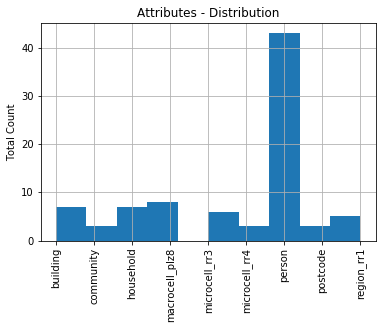

```python
feat_info['information_level'].hist()
plt.title('Attributes - Distribution')
plt.ylabel('Total Count')
plt.xticks(rotation='90')
plt.show()
```

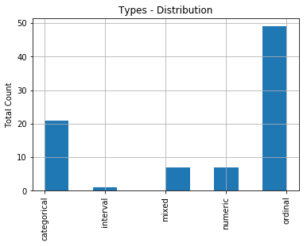

```python
feat_info['type'].hist()
plt.title('Types - Distribution')
plt.ylabel('Total Count')
plt.xticks(rotation='90')
plt.show()
```

```python
# Check the structure of the data after it's loaded (e.g. print the number of
# rows and columns, print the first few rows).
print(f'Azdias Dataframe Shape (Rows, Columns): {azdias.shape}')
```

```
Azdias Dataframe Shape (Rows, Columns): (891221, 85)
```

## Step 1: Preprocessing

### Step 1.1: Assess Missing Data

The feature summary file contains a summary of properties for each demographics data column. You will use this file to help you make cleaning decisions during this stage of the project. First of all, you should assess the demographics data in terms of missing data. Pay attention to the following points as you perform your analysis, and take notes on what you observe. Make sure that you fill in the **Discussion** cell with your findings and decisions at the end of each step that has one!

#### Step 1.1.1: Convert Missing Value Codes to NaNs

The fourth column of the feature attributes summary (loaded in above as `feat_info`) documents the codes from the data dictionary that indicate missing or unknown data. While the file encodes this as a list (e.g. `[-1,0]`), this will get read in as a string object. You'll need to do a little bit of parsing to make use of it to identify and clean the data. Convert data that matches a 'missing' or 'unknown' value code into a numpy NaN value. You might want to see how much data takes on a 'missing' or 'unknown' code, and how much data is naturally missing, as a point of interest.

**As one more reminder, you are encouraged to add additional cells to break up your analysis into manageable chunks.**

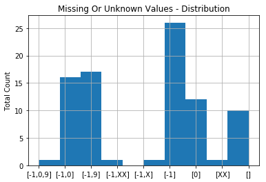

```python
feat_info['missing_or_unknown'].hist()
plt.title('Missing Or Unknown Values - Distribution')
plt.ylabel('Total Count')
plt.show()
```

The above lets us visually understand the distribution of missing or unkown value lists. One common element with several of these features is -1 being a missing or unknown value. There is some uncertainty on why such a number is "-1", but is good to note in the ongoing procedures.

```python
# Identify missing or unknown data values and convert them to NaNs.

def features_element_space_read(dataframe, numberOfColumns = None):
    listOfColumns = dataframe.columns.tolist()
    if numberOfColumns is None:
        for feature in listOfColumns:
            print(f'{feature}:   ', dataframe[feature].unique())
    else:
        for feature in listOfColumns[:numberOfColumns]:
            print(f'{feature}:   ', dataframe[feature].unique())

def missing_values_to_null(dataframe, metadataAttributes):
    for indx in range(len(metadataAttributes)):
        missingUnknown = metadataAttributes.iloc[indx]['missing_or_unknown']
        missingUnknown = missingUnknown.strip('[')
        missingUnknown = missingUnknown.strip(']')
        missingUnknown = missingUnknown.split(sep=',')
        missingUnknown = [int(value) if (value!='X' and value!='XX' and value!='')
                              else value for value in missingUnknown
                         ]
        if missingUnknown != ['']:
            dataframe = dataframe.replace({metadataAttributes.iloc[indx]['attribute']: missingUnknown}, np.nan)
    return(dataframe)

# Replace Nan & specified missing values with Numpy NaN.
azdias.replace('nan',np.NaN, inplace=True)
azdias = missing_values_to_null(azdias, feat_info)

# Observe Element Space for X number of columns in dataframe "azdias".
features_element_space_read(azdias, 2)
```

```
AGER_TYP:    [ nan   2.   3.   1.]
ALTERSKATEGORIE_GROB:    [  2.   1.   3.   4.  nan]
```

#### Step 1.1.2: Assess Missing Data in Each Column

How much missing data is present in each column? There are a few columns that are outliers in terms of the proportion of values that are missing. You will want to use matplotlib's [`hist()`](https://matplotlib.org/api/_as_gen/matplotlib.pyplot.hist.html) function to visualize the distribution of missing value counts to find these columns. Identify and document these columns. While some of these columns might have justifications for keeping or re-encoding the data, for this project you should just remove them from the dataframe. (Feel free to make remarks about these outlier columns in the discussion, however!)

For the remaining features, are there any patterns in which columns have, or share, missing data?

```python
listOfColumns = azdias.columns.tolist()
```

```python
missingNulls_summary = pd.DataFrame(azdias.isna().sum()).reset_index()
missingNulls_summary.columns = ['features','total_missing_values']
missingNulls_summary.head()
```

|  | features | total_missing_values |
| --- | --- | --- |
| 0 | AGER_TYP | 685843 |
| 1 | ALTERSKATEGORIE_GROB | 2881 |
| 2 | ANREDE_KZ | 0 |
| 3 | CJT_GESAMTTYP | 4854 |
| 4 | FINANZ_MINIMALIST | 0 |

```python
# Perform an assessment of how much missing data there is in each column of the
# dataset.

mostMissingRows = int(missingNulls_summary.sort_values("total_missing_values",
                         ascending=False
                     ).head(1)['total_missing_values'])
print(f"The most approximate missing rows with missing values can go up to {mostMissingRows} rows.")
```

```
The most approximate missing rows with missing values can go up to 889061 rows.
```

The following is a visualization for columns having 1+ missing values.

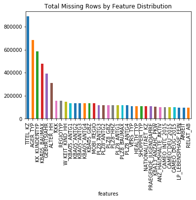

```python
missingNulls_summary.sort_values("total_missing_values",
                         ascending=False
                     )[:35].plot(x = 'features',
                        y = 'total_missing_values', kind = 'bar', legend=False)
plt.title('Total Missing Rows by Feature Distribution')
plt.show()
```

### Patterns in missing data for each Column

```python
topFeaturesMissingRows_fullList = missingNulls_summary.sort_values("total_missing_values",
                         ascending=False)
```

```python
topFeaturesMissingRows_list = topFeaturesMissingRows_fullList[:35]['features'].tolist()
```

```python
top35MissingFeatures = feat_info[feat_info['attribute'].isin(topFeaturesMissingRows_list)]
```

```python
top35MissingFeatures
```

|  | attribute | information_level | type | missing_or_unknown |
| --- | --- | --- | --- | --- |
| 0 | AGER_TYP | person | categorical | [-1,0] |
| 11 | GEBURTSJAHR | person | numeric | [0] |
| 14 | HEALTH_TYP | person | ordinal | [-1,0] |
| 15 | LP_LEBENSPHASE_FEIN | person | mixed | [0] |
| 21 | NATIONALITAET_KZ | person | categorical | [-1,0] |
| 22 | PRAEGENDE_JUGENDJAHRE | person | mixed | [-1,0] |
| 38 | SHOPPER_TYP | person | categorical | [-1] |
| 40 | TITEL_KZ | person | categorical | [-1,0] |
| 41 | VERS_TYP | person | categorical | [-1] |
| 43 | ALTER_HH | household | interval | [0] |
| 47 | KK_KUNDENTYP | household | categorical | [-1] |
| 48 | W_KEIT_KIND_HH | household | ordinal | [-1,0] |
| 50 | ANZ_HAUSHALTE_AKTIV | building | numeric | [0] |
| 57 | CAMEO_DEUG_2015 | microcell_rr4 | categorical | [-1,X] |
| 58 | CAMEO_DEU_2015 | microcell_rr4 | categorical | [XX] |
| 59 | CAMEO_INTL_2015 | microcell_rr4 | mixed | [-1,XX] |
| 60 | KBA05_ANTG1 | microcell_rr3 | ordinal | [-1] |
| 61 | KBA05_ANTG2 | microcell_rr3 | ordinal | [-1] |
| 62 | KBA05_ANTG3 | microcell_rr3 | ordinal | [-1] |
| 63 | KBA05_ANTG4 | microcell_rr3 | ordinal | [-1] |
| 64 | KBA05_BAUMAX | microcell_rr3 | mixed | [-1,0] |
| 65 | KBA05_GBZ | microcell_rr3 | ordinal | [-1,0] |
| 70 | KKK | region_rr1 | ordinal | [-1,0] |
| 71 | MOBI_REGIO | region_rr1 | ordinal | [] |
| 73 | REGIOTYP | region_rr1 | ordinal | [-1,0] |
| 74 | KBA13_ANZAHL_PKW | macrocell_plz8 | numeric | [] |
| 75 | PLZ8_ANTG1 | macrocell_plz8 | ordinal | [-1] |
| 76 | PLZ8_ANTG2 | macrocell_plz8 | ordinal | [-1] |
| 77 | PLZ8_ANTG3 | macrocell_plz8 | ordinal | [-1] |
| 78 | PLZ8_ANTG4 | macrocell_plz8 | ordinal | [-1] |
| 79 | PLZ8_BAUMAX | macrocell_plz8 | mixed | [-1,0] |
| 80 | PLZ8_HHZ | macrocell_plz8 | ordinal | [-1] |
| 81 | PLZ8_GBZ | macrocell_plz8 | ordinal | [-1] |
| 82 | ARBEIT | community | ordinal | [-1,9] |
| 84 | RELAT_AB | community | ordinal | [-1,9] |

```python
# Identify all rows with one or more Null values.

allMissingFeatures_list = missingNulls_summary[missingNulls_summary.sort_values("total_missing_values",
                         ascending=False
                     )['total_missing_values'] > 0]['features'].tolist()
```

```python
allMissingFeatures = feat_info[feat_info['attribute'].isin(allMissingFeatures_list)]
totalFeatures_missingValues = len(allMissingFeatures['attribute'])
```

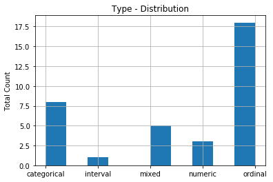

```python
# Feature Type for Top ranked 35 features with missing data
top35MissingFeatures['type'].hist()
plt.title('Type - Distribution')
plt.ylabel('Total Count')
plt.show()
```

[output not shown]

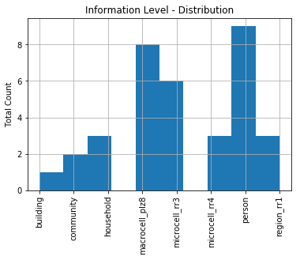

```python
# Feature Type for Top ranked 35 features with missing data
print("Feature Type for Top ranked 35 features with missing data")
top35MissingFeatures['information_level'].hist()
plt.title('Information Level - Distribution')
plt.ylabel('Total Count')
plt.xticks(rotation = 90)
plt.show()
```

#### Features with 30%+ Missing Values

There is a consideration to drop all 35+ columns, with missing values. However, dropping all those columns would result in missing binary categorical columns, and ~4 multi-level ordinal columns.

Instead of dropping all columns, we remove all columns with 30+% of values missing from them

```python
threshold = 30 # 30% threshold for upcoming filter implementation.

totalNullValues = azdias.isnull().sum()
missingColumn_proportions =(totalNullValues / len(azdias) )*100
missingColumn_proportionsThreshold = missingColumn_proportions[missingColumn_proportions > threshold]
```

```python
missingColumn_proportionsThreshold.index.tolist()
```

```
['AGER_TYP',
 'GEBURTSJAHR',
 'TITEL_KZ',
 'ALTER_HH',
 'KK_KUNDENTYP',
 'KBA05_BAUMAX']
```

Remove the outlier columns from the dataset. (You'll perform other data engineering tasks such as re-encoding and imputation later.)

```python
proportionalNonNullValues = [i for i in feat_info['attribute']
                                if i not in missingColumn_proportionsThreshold.index.tolist()]

azdiasExtraction_df = azdias[proportionalNonNullValues]
```

#### Discussion 1.1.2: Assess Missing Data in Each Column

```python
print(f'azdias Dataframe Shape ---- (Rows, Columns): {azdias.shape}')
```

```
azdias Dataframe Shape ---- (Rows, Columns): (891221, 85)
```

```python
missingColumn_proportionsThreshold.index.tolist()
```

```
['AGER_TYP',
 'GEBURTSJAHR',
 'TITEL_KZ',
 'ALTER_HH',
 'KK_KUNDENTYP',
 'KBA05_BAUMAX']
```

The following is one of hypothesis that could explain why there is missing data.

```python
missingFeaturesProp = feat_info[feat_info['attribute'].isin(missingColumn_proportionsThreshold.index.tolist())]
```

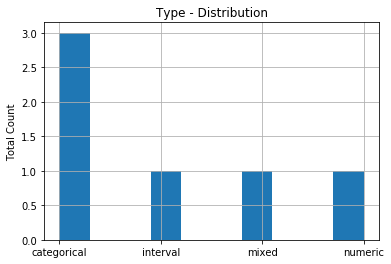

```python
# Feature Type for Top ranked 35 features with missing data
missingFeaturesProp['type'].hist()
plt.title('Type - Distribution')
plt.ylabel('Total Count')
plt.show()
```

We observe that categorical data appear to have quite a few missing values missing.

I was considering that this could either be a lack of categorization, or a "blank" categorization could actually have some classified meaning to it. To actually see what is a true missing value or incorrectly labeled value for each column, we look at the `missing_or_unknown` column to see the anticpiated behaviours of this missing data.

```python
missingFeaturesProp
```

|  | attribute | information_level | type | missing_or_unknown |
| --- | --- | --- | --- | --- |
| 0 | AGER_TYP | person | categorical | [-1,0] |
| 11 | GEBURTSJAHR | person | numeric | [0] |
| 40 | TITEL_KZ | person | categorical | [-1,0] |
| 43 | ALTER_HH | household | interval | [0] |
| 47 | KK_KUNDENTYP | household | categorical | [-1] |
| 64 | KBA05_BAUMAX | microcell_rr3 | mixed | [-1,0] |

Doing some additional research, we find that these columns with 30% of data missing are defined as:

- **AGER_TYP ( person & categorical)**
  - Best-ager typology
- **GEBURTSJAHR (person & numeric)**
  - Year of birth
- **TITEL_KZ (person & categorical)**
  - Academic title flag (e.g Dr, Miss, Doctor, etc.)
- **ALTER_HH (household & interval)**
  - Birthdate
- **KK_KUNDENTYP (household & categorical)**
  - Consumer pattern over past 12 months (e.g. active, inactive, passive customer)
- **KBA05_BAUMAX**
  - Residing building types within the microcell

#### Step 1.1.3: Assess Missing Data in Each Row

Now, you'll perform a similar assessment for the rows of the dataset. How much data is missing in each row? As with the columns, you should see some groups of points that have a very different numbers of missing values. Divide the data into two subsets: one for data points that are above some threshold for missing values, and a second subset for points below that threshold.

In order to know what to do with the outlier rows, we should see if the distribution of data values on columns that are not missing data (or are missing very little data) are similar or different between the two groups. Select at least five of these columns and compare the distribution of values.

- You can use seaborn's [`countplot()`](https://seaborn.pydata.org/generated/seaborn.countplot.html) function to create a bar chart of code frequencies and matplotlib's [`subplot()`](https://matplotlib.org/api/_as_gen/matplotlib.pyplot.subplot.html) function to put bar charts for the two subplots side by side.
- To reduce repeated code, you might want to write a function that can perform this comparison, taking as one of its arguments a column to be compared.

Depending on what you observe in your comparison, this will have implications on how you approach your conclusions later in the analysis. If the distributions of non-missing features look similar between the data with many missing values and the data with few or no missing values, then we could argue that simply dropping those points from the analysis won't present a major issue. On the other hand, if the data with many missing values looks very different from the data with few or no missing values, then we should make a note on those data as special. We'll revisit these data later on. **Either way, you should continue your analysis for now using just the subset of the data with few or no missing values.**

```python
# How much data is missing in each row of the dataset?
thresholdAverageNulls = np.mean(azdiasExtraction_df.isnull().sum(axis=1))
thresholdAverageNulls_mod = thresholdAverageNulls * 3
```

```python
# Write code to divide the data into two subsets based on the number of missing
# values in each row.
azdiasExtraction_belowThreshold_df = azdiasExtraction_df[azdiasExtraction_df.isnull().sum(axis=1) <=
                                                         thresholdAverageNulls]

azdiasExtraction_aboveThreshold_df = azdiasExtraction_df[azdiasExtraction_df.isnull().sum(axis=1) >
                                                         thresholdAverageNulls]
```

```python
azdiasColList = azdiasExtraction_belowThreshold_df.columns.tolist()
```

```
The following seperates distributions of # of rows that  have missing values above and below some threshold
(Mean: 5.65)
```

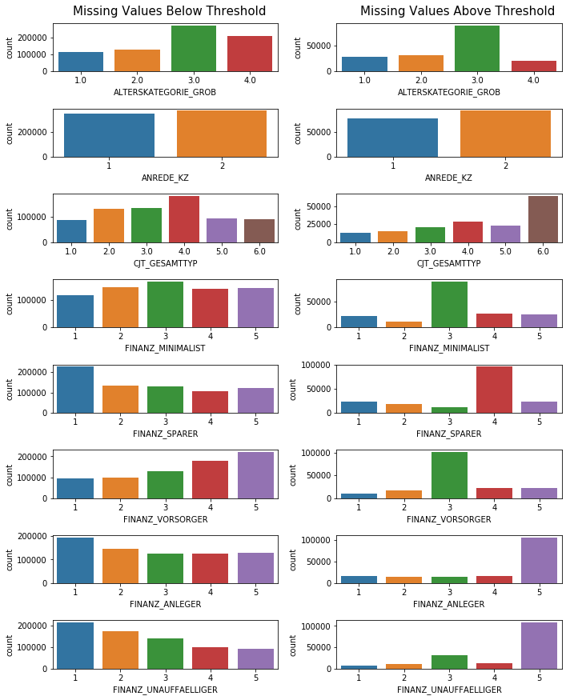

```python
# Compare the distribution of values for at least five columns where there are
# no or few missing values, between the two subsets.

fig, axs = plt.subplots(8, 2, figsize=(10, 12), sharey=False, sharex =False)
plt.figtext(.3,1,"Missing Values Below Threshold", va="center", ha="center", size=15)
plt.figtext(.8,1,"Missing Values Above Threshold", va="center", ha="center", size=15)
fig.subplots_adjust(top=5)

for i in range(0,8):
    sns.countplot(x= azdiasColList[i], data = azdiasExtraction_belowThreshold_df, ax= axs[i,0])
    sns.countplot(x= azdiasColList[i], data = azdiasExtraction_aboveThreshold_df, ax= axs[i,1])
fig.tight_layout()

print("The following seperates distributions of # of rows that ",
      f"have missing values above and below some threshold \n(Mean: {round(thresholdAverageNulls,2)})")
plt.show()
```

#### Discussion 1.1.3: Assess Missing Data in Each Row

Are the data with lots of missing values are qualitatively different from data with few or no missing values?)

##### Ans:

In particular, it could be that financial information in `finanz_` features are hidden from this dataset, or excluded before delivery.

Categorizations like `CJT_GESAMTTYP` (Customer-Journey-Typology) with cross-channel restrictions will have consequential missing data due to such lack of restrictions for the customer journey.

This is the observation, but not quite a conclusion.

To make a more qualitative solution in regards to if there is a lot of data missing, we implement a comparison test using the `Kolmogorov-Smirnov` test (K-S Test) for continuous distribution, seen below using `ks_2samp` object.

Our hypothesis is that there is no statistical significant difference between the our two sample datasets, under & over threshold.

Using the K-S Test, if we have a p-value from our subsequent statistic calculation be less than 0.05, then we can reject our hypothesis to say there is a statistical significant difference. Else, we cannot.

```python
# Improt object for the `Kolmogorov-Smirnov` test.
from scipy.stats import ks_2samp
```

```python
ks_2samp(azdiasExtraction_belowThreshold_df.isnull().sum(),
         azdiasExtraction_aboveThreshold_df.isnull().sum())
```

```
Ks_2sampResult(statistic=0.59493670886075956, pvalue=4.169629519975283e-13)
```

Using the K-S test statistic calcualtion, we observe an outcome of test statistic ~= `0.59` and p-value = `4.169629519975283e-13`.

With our `p-value` < 0.05, we conclude there is a statistical significant difference between the two datasets.

### Step 1.2: Select and Re-Encode Features

Checking for missing data isn't the only way in which you can prepare a dataset for analysis. Since the unsupervised learning techniques to be used will only work on data that is encoded numerically, you need to make a few encoding changes or additional assumptions to be able to make progress. In addition, while almost all of the values in the dataset are encoded using numbers, not all of them represent numeric values. Check the third column of the feature summary (`feat_info`) for a summary of types of measurement.

- For numeric and interval data, these features can be kept without changes.
- Most of the variables in the dataset are ordinal in nature. While ordinal values may technically be non-linear in spacing, make the simplifying assumption that the ordinal variables can be treated as being interval in nature (that is, kept without any changes).
- Special handling may be necessary for the remaining two variable types: categorical, and 'mixed'.

In the first two parts of this sub-step, you will perform an investigation of the categorical and mixed-type features and make a decision on each of them, whether you will keep, drop, or re-encode each. Then, in the last part, you will create a new data frame with only the selected and engineered columns.

Data wrangling is often the trickiest part of the data analysis process, and there's a lot of it to be done here. But stick with it: once you're done with this step, you'll be ready to get to the machine learning parts of the project!

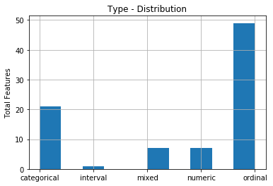

```python
# How many features are there of each data type?
feat_info['type'].hist()
plt.title('Type - Distribution')
plt.ylabel('Total Features')
plt.show()
```

#### Step 1.2.1: Re-Encode Categorical Features

For categorical data, you would ordinarily need to encode the levels as dummy variables. Depending on the number of categories, perform one of the following:

- For binary (two-level) categoricals that take numeric values, you can keep them without needing to do anything.
- There is one binary variable that takes on non-numeric values. For this one, you need to re-encode the values as numbers or create a dummy variable.
- For multi-level categoricals (three or more values), you can choose to encode the values using multiple dummy variables (e.g. via [OneHotEncoder](http://scikit-learn.org/stable/modules/generated/sklearn.preprocessing.OneHotEncoder.html)), or (to keep things straightforward) just drop them from the analysis. As always, document your choices in the Discussion section.

```python
feature_infoClean = feat_info[feat_info['attribute'].isin(azdiasExtraction_belowThreshold_df.columns.tolist())]
```

```python
# Assess categorical variables: which are binary, which are multi-level, and
# which one needs to be re-encoded?
categoricalFeatures = feature_infoClean[feature_infoClean["type"]=="categorical"]["attribute"]

binaryFeature = []
multiLevelFeature=[]
for feature in categoricalFeatures:
    if (len(azdiasExtraction_df[feature].unique()) == 2):
        binaryFeature.append(feature)
    elif (len(azdiasExtraction_df[feature].unique()) > 2):
        multiLevelFeature.append(feature)

print(f'Binary Features Remaining: \n{binaryFeature}\n')
print(f'Multi-level Features Remaining: \n{multiLevelFeature}')
```

```
Binary Features Remaining:
['ANREDE_KZ', 'GREEN_AVANTGARDE']

Multi-level Features Remaining:
['CJT_GESAMTTYP', 'FINANZTYP', 'GFK_URLAUBERTYP', 'LP_FAMILIE_FEIN', 'LP_FAMILIE_GROB', 'LP_STATUS_FEIN', 'LP_STATUS_GROB', 'NATIONALITAET_KZ', 'SHOPPER_TYP', 'SOHO_KZ', 'VERS_TYP', 'ZABEOTYP', 'GEBAEUDETYP', 'OST_WEST_KZ', 'CAMEO_DEUG_2015', 'CAMEO_DEU_2015']
```

```python
# ANREDE_KZ Stands for gender types. The values in here are 1 & 2.
# We need to convert them to 0 & 1, respectively.

# Set Male value from 1 ---> 0
azdiasExtraction_belowThreshold_df['ANREDE_KZ'].replace({1:0},inplace=True)
# Set Female value from 1 ---> 0
azdiasExtraction_belowThreshold_df['ANREDE_KZ'].replace({2:1 },inplace=True)
```

```python
# Multi-level features have been transformed to one-hot coding equivalents.
selectedColumns_oneHotEncode = ['SHOPPER_TYP', 'GEBAEUDETYP']
```

```python
# Preserve feature OST_WEST_KZ
multiLevelFeature.remove('OST_WEST_KZ')
```

```python
azdiasSelectedTransformed = azdiasExtraction_belowThreshold_df[selectedColumns_oneHotEncode].fillna(0)
```

```python
azdiasExtraction_df = pd.concat([azdiasExtraction_belowThreshold_df,
                                 pd.get_dummies(azdiasExtraction_belowThreshold_df['SHOPPER_TYP'],
                                                prefix='SHOPPER_TYP'),
                                pd.get_dummies(azdiasExtraction_belowThreshold_df['GEBAEUDETYP'],
                                               prefix='GEBAEUDETYP')], axis=1)
```

```python
# now drop the original 'country' column (you don't need it anymore)
azdiasExtraction_df.drop(multiLevelFeature,axis=1, inplace=True)
```

#### Discussion 1.2.1: Re-Encode Categorical Features

##### Ans:

**binary** categorical feature **ANREDE_KZ** stands for gender types. The values in here are 1 & 2. We converted said values to 0 & 1, respectively.

However, there were some **multi-level** features remaining.

> - CJT_GESAMTTYP
>   - Customer-Journey-Typology
> - FINANZTYP
>   - Most descriptive financial type for individual
> - GFK_URLAUBERTYP
>   - Vacation Habits
> - LP_FAMILIE_FEIN
>   - Family type
> - LP_FAMILIE_GROB
>   - Family type
> - LP_STATUS_FEIN
>   - Social Status
> - LP_STATUS_GROB
>   - Social Status
> - NATIONALITAET_KZ
>   - Nationality based on given name analysis
> - SHOPPER_TYP
>   - Shopper Typology
> - SOHO_KZ
>   - Small/ Home Office Flag
> - VERS_TYP
>   - Insurance Policy
> - ZABEOTYP
>   - Energy consumption typology
> - GEBAEUDETYP
>   - Type of building (residential vs. commercial)
> - OST_WEST_KZ
>   - Building location
> - CAMEO_DEUG_2015
>   - Wealth / Life Stage Typology
> - CAMEO_DEU_2015

We proceed with transforming a selected amount of features into their own respective binary features through "One Hot Encoding".

These features were

```python
azdiasExtraction_df.head().iloc[:,-10:]
```

|  | SHOPPER_TYP_1.0 | SHOPPER_TYP_2.0 | SHOPPER_TYP_3.0 | GEBAEUDETYP_1.0 | GEBAEUDETYP_2.0 | GEBAEUDETYP_3.0 | GEBAEUDETYP_4.0 | GEBAEUDETYP_5.0 | GEBAEUDETYP_6.0 | GEBAEUDETYP_8.0 |
| --- | --- | --- | --- | --- | --- | --- | --- | --- | --- | --- |
| 1 | 0 | 0 | 1 | 0 | 0 | 0 | 0 | 0 | 0 | 1 |
| 2 | 0 | 1 | 0 | 1 | 0 | 0 | 0 | 0 | 0 | 0 |
| 4 | 0 | 1 | 0 | 1 | 0 | 0 | 0 | 0 | 0 | 0 |
| 5 | 0 | 0 | 0 | 1 | 0 | 0 | 0 | 0 | 0 | 0 |
| 6 | 1 | 0 | 0 | 1 | 0 | 0 | 0 | 0 | 0 | 0 |

#### Step 1.2.2: Engineer Mixed-Type Features

There are a handful of features that are marked as "mixed" in the feature summary that require special treatment in order to be included in the analysis. There are two in particular that deserve attention; the handling of the rest are up to your own choices:

- "PRAEGENDE_JUGENDJAHRE" combines information on three dimensions: generation by decade, movement (mainstream vs. avantgarde), and nation (east vs. west). While there aren't enough levels to disentangle east from west, you should create two new variables to capture the other two dimensions: an interval-type variable for decade, and a binary variable for movement.
- "CAMEO_INTL_2015" combines information on two axes: wealth and life stage. Break up the two-digit codes by their 'tens'-place and 'ones'-place digits into two new ordinal variables (which, for the purposes of this project, is equivalent to just treating them as their raw numeric values).
- If you decide to keep or engineer new features around the other mixed-type features, make sure you note your steps in the Discussion section.

Be sure to check `Data_Dictionary.md` for the details needed to finish these tasks.

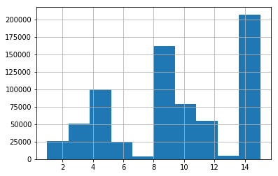

```python
# Investigate "PRAEGENDE_JUGENDJAHRE" and engineer two new variables.
azdiasExtraction_df['PRAEGENDE_JUGENDJAHRE'].hist()
plt.show()
```

We observe a couple of examples that the higher proportion of rows contain labelings for the following, in order:

- 14: Mainstream, E+W
- 9: Avantgarde, E+W

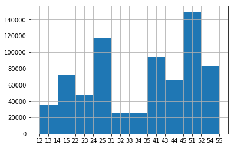

```python
# Investigate "CAMEO_INTL_2015" and engineer two new variables.

azdiasExtraction_df['CAMEO_INTL_2015'].hist()
plt.show()
```

```python
def praegende_to_era_category(era):
    if era == 1 or era == 2:
        return('40s')
    elif era == 3 or era ==4:
        return('50s')
    elif era == 5 or era == 6 or era ==7:
        return('60s')
    elif era == 8 or era == 9:
        return('70s')
    elif era == 10 or era == 11 or era == 12 or era == 13:
        return('80s')
    else:
        return('')
def praegende_to_mainstream_category(era):
    # Mainstream
    if era == 1 or era == 3 or era == 5 or era ==8 or era ==10 or era ==12 or era ==14:
        return('Mainstream')
    # Avantgarde
    if era == 2 or era == 4 or era == 6 or era ==7 or era ==9 or era ==11 or era ==13 or era ==15:
        return('Avantgarde')
    else:
        ''
azdiasExtraction_df['PRAEGENDE_JUGENDJAHRE_ERA'] = azdiasExtraction_df['PRAEGENDE_JUGENDJAHRE'].transform(
                                                            praegende_to_era_category)
azdiasExtraction_df['PRAEGENDE_JUGENDJAHRE_MAINSTREAM'] = azdiasExtraction_df['PRAEGENDE_JUGENDJAHRE'].transform(
                                                            praegende_to_mainstream_category)
```

We alsop consider the feature `OST_WEST_KZ`, West or East Germany living location, as an additional transformation into our feature engineering process. Labels are as follows:

- W: West Germany
- O: East Germany

```python
def ost_west_to_location_category(location):
    if location == 'W':
        return('West')
    elif location == 'O':
        return('East')
    else:
        return('NA')
```

```python
def cameo_to_class_type_category(class_type):
    if class_type == 11 or class_type == 12 or class_type == 13 or class_type == 14 or class_type == 15:
        return('Wealthy')
    elif class_type == 21 or class_type == 22 or class_type == 23 or class_type == 24 or class_type == 25:
        return('Prosperous')
    elif class_type == 31 or class_type == 32 or class_type == 33 or class_type == 34 or class_type == 35:
        return('Comfortable')
    elif class_type == 41 or class_type == 42 or class_type == 43 or class_type == 44 or class_type == 45:
        return('Less Affluent')
    elif class_type == 51 or class_type == 52 or class_type == 53 or class_type == 54 or class_type == 55:
        return('Poorer')
    else:
        return('NA')
def cameo_to_family_category(class_type):
    if class_type == 11 or class_type == 21 or class_type == 31 or class_type == 41 or class_type == 51:
        return('Pre-Family Couples & Singles')
    elif class_type == 12 or class_type == 22 or class_type == 32 or class_type == 42 or class_type == 52:
        return('Young Couples With Children')
    elif class_type == 13 or class_type == 23 or class_type == 33 or class_type == 43 or class_type == 53:
        return('Families With School Age Children')
    elif class_type == 14 or class_type == 24 or class_type == 34 or class_type == 44 or class_type == 54:
        return('Older Families &  Mature Couples')
    elif class_type == 15 or class_type == 25 or class_type == 35 or class_type == 45 or class_type == 55:
        return('Elders In Retirement')
    else:
        return('NA')
```

```python
azdiasExtraction_df['OST_WEST_KZ_LOCATION'] = azdiasExtraction_df['OST_WEST_KZ'].transform(ost_west_to_location_category)

azdiasExtraction_df.drop('OST_WEST_KZ', axis=1, inplace=True)
```

```python
azdiasExtraction_df['CAMEO_INTL_2015_CLASS_TYPE'] = azdiasExtraction_df['CAMEO_INTL_2015'].transform(cameo_to_class_type_category)
azdiasExtraction_df['CAMEO_INTL_2015_FAMILY'] = azdiasExtraction_df['CAMEO_INTL_2015'].transform(cameo_to_family_category)

azdiasExtraction_df.drop('CAMEO_INTL_2015',axis=1, inplace=True)
azdiasExtraction_df.drop('PRAEGENDE_JUGENDJAHRE',axis=1, inplace=True)
```

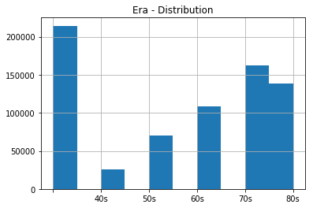

```python
azdiasExtraction_df['PRAEGENDE_JUGENDJAHRE_ERA'].hist()
plt.title('Era - Distribution')
plt.show()
```

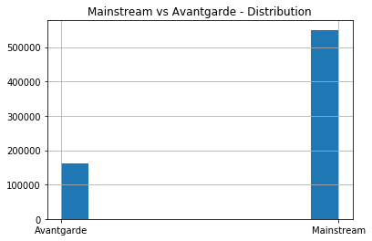

```python
azdiasExtraction_df['PRAEGENDE_JUGENDJAHRE_MAINSTREAM'].hist()
plt.title('Mainstream vs Avantgarde - Distribution')

plt.show()
```

```python
azdiasExtraction_df = pd.concat([azdiasExtraction_df, pd.get_dummies(azdiasExtraction_df['OST_WEST_KZ_LOCATION'], prefix='OST_WEST_KZ_LOCATION'),\
                                pd.get_dummies(azdiasExtraction_df['OST_WEST_KZ_LOCATION'], prefix='OST_WEST_KZ_LOCATION')\
                                ], axis=1)
```

```python
azdiasExtraction_df = pd.concat([azdiasExtraction_df, pd.get_dummies(azdiasExtraction_df['PRAEGENDE_JUGENDJAHRE_ERA'], prefix='PRAEGENDE_JUGENDJAHRE_ERA'),\
                                pd.get_dummies(azdiasExtraction_df['PRAEGENDE_JUGENDJAHRE_MAINSTREAM'], prefix='PRAEGENDE_JUGENDJAHRE_MAINSTREAM')\
                                ], axis=1)
```

```python
azdiasExtraction_df = pd.concat([azdiasExtraction_df, pd.get_dummies(azdiasExtraction_df['CAMEO_INTL_2015_CLASS_TYPE'], prefix='CAMEO_INTL_2015_CLASS_TYPE'),\
                                pd.get_dummies(azdiasExtraction_df['CAMEO_INTL_2015_FAMILY'], prefix='CAMEO_INTL_2015_FAMILY')\
                                ], axis=1)
```

```python
# Remove base features from feature engineering process
azdiasExtraction_df.drop('PRAEGENDE_JUGENDJAHRE_MAINSTREAM', axis=1, inplace = True)
azdiasExtraction_df.drop('OST_WEST_KZ_LOCATION', axis=1,inplace = True)
azdiasExtraction_df.drop('PRAEGENDE_JUGENDJAHRE_ERA', axis=1,inplace = True)
```

```python
#Last 10 columns of the dataset
azdiasExtraction_df.iloc[:3,:-10]
```

|  | ALTERSKATEGORIE_GROB | ANREDE_KZ | FINANZ_MINIMALIST | FINANZ_SPARER | FINANZ_VORSORGER | FINANZ_ANLEGER | FINANZ_UNAUFFAELLIGER | FINANZ_HAUSBAUER | GREEN_AVANTGARDE | HEALTH_TYP | ... | GEBAEUDETYP_4.0 | GEBAEUDETYP_5.0 | GEBAEUDETYP_6.0 | GEBAEUDETYP_8.0 | CAMEO_INTL_2015_CLASS_TYPE | CAMEO_INTL_2015_FAMILY | OST_WEST_KZ_LOCATION_East | OST_WEST_KZ_LOCATION_West | OST_WEST_KZ_LOCATION_East | OST_WEST_KZ_LOCATION_West |
| --- | --- | --- | --- | --- | --- | --- | --- | --- | --- | --- | --- | --- | --- | --- | --- | --- | --- | --- | --- | --- | --- |
| 1 | 1.0 | 1 | 1 | 5 | 2 | 5 | 4 | 5 | 0 | 3.0 | ... | 0 | 0 | 0 | 1 | NA | NA | 0 | 1 | 0 | 1 |
| 2 | 3.0 | 1 | 1 | 4 | 1 | 2 | 3 | 5 | 1 | 3.0 | ... | 0 | 0 | 0 | 0 | NA | NA | 0 | 1 | 0 | 1 |
| 4 | 3.0 | 0 | 4 | 3 | 4 | 1 | 3 | 2 | 0 | 3.0 | ... | 0 | 0 | 0 | 0 | NA | NA | 0 | 1 | 0 | 1 |

3 rows × 78 columns

#### Discussion 1.2.2: Engineer Mixed-Type Features

Which mixed-feature types did you keep, which did you drop, and what engineering steps did you perform?)

#### Ans:

```python
multiLevelFeature
```

```
['CJT_GESAMTTYP',
 'FINANZTYP',
 'GFK_URLAUBERTYP',
 'LP_FAMILIE_FEIN',
 'LP_FAMILIE_GROB',
 'LP_STATUS_FEIN',
 'LP_STATUS_GROB',
 'NATIONALITAET_KZ',
 'SHOPPER_TYP',
 'SOHO_KZ',
 'VERS_TYP',
 'ZABEOTYP',
 'GEBAEUDETYP',
 'CAMEO_DEUG_2015',
 'CAMEO_DEU_2015']
```

So why did we choose the aforementioned transformations for 2 mixed feature-types then?

We've only considered permutations of `CAMEO_INTL_2015` & `PRAEGENDE_JUGENDJAHRE` on the consideration of family types & their respective culture-fit into the consideration of their willingness to adopt the company service.

**That is**, does being mainstream and/or a certain class & family type affect ones willingess to adopt to a company type as well?

#### Step 1.2.3: Complete Feature Selection

In order to finish this step up, you need to make sure that your data frame now only has the columns that you want to keep. To summarize, the dataframe should consist of the following:

- All numeric, interval, and ordinal type columns from the original dataset.
- Binary categorical features (all numerically-encoded).
- Engineered features from other multi-level categorical features and mixed features.

Make sure that for any new columns that you have engineered, that you've excluded the original columns from the final dataset. Otherwise, their values will interfere with the analysis later on the project. For example, you should not keep "PRAEGENDE_JUGENDJAHRE", since its values won't be useful for the algorithm: only the values derived from it in the engineered features you created should be retained. As a reminder, your data should only be from **the subset with few or no missing values**.

```python
azdiasExtraction_df.describe()
```

|  | ALTERSKATEGORIE_GROB | ANREDE_KZ | FINANZ_MINIMALIST | FINANZ_SPARER | FINANZ_VORSORGER | FINANZ_ANLEGER | FINANZ_UNAUFFAELLIGER | FINANZ_HAUSBAUER | GREEN_AVANTGARDE | HEALTH_TYP | ... | PRAEGENDE_JUGENDJAHRE_ERA_ | PRAEGENDE_JUGENDJAHRE_ERA_40s | PRAEGENDE_JUGENDJAHRE_ERA_50s | PRAEGENDE_JUGENDJAHRE_ERA_60s | PRAEGENDE_JUGENDJAHRE_ERA_70s | PRAEGENDE_JUGENDJAHRE_ERA_80s | PRAEGENDE_JUGENDJAHRE_MAINSTREAM_Avantgarde | PRAEGENDE_JUGENDJAHRE_MAINSTREAM_Mainstream | CAMEO_INTL_2015_CLASS_TYPE_NA | CAMEO_INTL_2015_FAMILY_NA |
| --- | --- | --- | --- | --- | --- | --- | --- | --- | --- | --- | --- | --- | --- | --- | --- | --- | --- | --- | --- | --- | --- |
| count | 718093.000000 | 719624.000000 | 719624.000000 | 719624.000000 | 719624.000000 | 719624.00000 | 719624.000000 | 719624.000000 | 719624.000000 | 704814.000000 | ... | 719624.000000 | 719624.000000 | 719624.000000 | 719624.000000 | 719624.000000 | 719624.000000 | 719624.000000 | 719624.000000 | 719624.0 | 719624.0 |
| mean | 2.793277 | 0.516453 | 3.065229 | 2.669370 | 3.458492 | 2.79274 | 2.562273 | 3.165282 | 0.225177 | 2.213222 | ... | 0.297933 | 0.036086 | 0.097889 | 0.150800 | 0.225043 | 0.192250 | 0.225177 | 0.764590 | 1.0 | 1.0 |
| std | 1.031134 | 0.499730 | 1.361379 | 1.474188 | 1.387388 | 1.45717 | 1.375376 | 1.377705 | 0.417699 | 0.755041 | ... | 0.457350 | 0.186503 | 0.297164 | 0.357854 | 0.417611 | 0.394069 | 0.417699 | 0.424255 | 0.0 | 0.0 |
| min | 1.000000 | 0.000000 | 1.000000 | 1.000000 | 1.000000 | 1.00000 | 1.000000 | 1.000000 | 0.000000 | 1.000000 | ... | 0.000000 | 0.000000 | 0.000000 | 0.000000 | 0.000000 | 0.000000 | 0.000000 | 0.000000 | 1.0 | 1.0 |
| 25% | 2.000000 | 0.000000 | 2.000000 | 1.000000 | 2.000000 | 1.00000 | 1.000000 | 2.000000 | 0.000000 | 2.000000 | ... | 0.000000 | 0.000000 | 0.000000 | 0.000000 | 0.000000 | 0.000000 | 0.000000 | 1.000000 | 1.0 | 1.0 |
| 50% | 3.000000 | 1.000000 | 3.000000 | 2.000000 | 4.000000 | 3.00000 | 2.000000 | 3.000000 | 0.000000 | 2.000000 | ... | 0.000000 | 0.000000 | 0.000000 | 0.000000 | 0.000000 | 0.000000 | 0.000000 | 1.000000 | 1.0 | 1.0 |
| 75% | 4.000000 | 1.000000 | 4.000000 | 4.000000 | 5.000000 | 4.00000 | 4.000000 | 4.000000 | 0.000000 | 3.000000 | ... | 1.000000 | 0.000000 | 0.000000 | 0.000000 | 0.000000 | 0.000000 | 0.000000 | 1.000000 | 1.0 | 1.0 |
| max | 4.000000 | 1.000000 | 5.000000 | 5.000000 | 5.000000 | 5.00000 | 5.000000 | 5.000000 | 1.000000 | 3.000000 | ... | 1.000000 | 1.000000 | 1.000000 | 1.000000 | 1.000000 | 1.000000 | 1.000000 | 1.000000 | 1.0 | 1.0 |

8 rows × 86 columns

```python
# If there are other re-engineering tasks you need to perform, make sure you
# take care of them here. (Dealing with missing data will come in step 2.1.)
azdiasExtraction_df.isna().sum().sort_values(ascending=False)[azdiasExtraction_df.isna().sum().sort_values(ascending=False) >0]
```

```
W_KEIT_KIND_HH          39782
KKK                     38742
REGIOTYP                38742
LP_LEBENSPHASE_FEIN     19703
LP_LEBENSPHASE_GROB     19576
HEALTH_TYP              14810
RELAT_AB                 3607
ARBEIT                   3607
ORTSGR_KLS9              3531
ANZ_HAUSHALTE_AKTIV      2645
ALTERSKATEGORIE_GROB     1531
KBA13_ANZAHL_PKW          642
ANZ_HH_TITEL              603
BALLRAUM                  442
INNENSTADT                442
EWDICHTE                  442
KONSUMNAEHE                44
GEBAEUDETYP_RASTER          5
dtype: int64
```

```python
# Do whatever you need to in order to ensure that the dataframe only contains
# the columns that should be passed to the algorithm functions.

mixed_features = feature_infoClean[feature_infoClean["type"]=="mixed"]["attribute"]
print(mixed_features.tolist())
```

```
['LP_LEBENSPHASE_FEIN', 'LP_LEBENSPHASE_GROB', 'PRAEGENDE_JUGENDJAHRE', 'WOHNLAGE', 'CAMEO_INTL_2015', 'PLZ8_BAUMAX']
```

```python
for feature in mixed_features:
    try:
        azdiasExtraction_df.drop(feature, axis=1, inplace=True)
    except KeyError:
        continue
```

### Step 1.3: Create a Cleaning Function

Even though you've finished cleaning up the general population demographics data, it's important to look ahead to the future and realize that you'll need to perform the same cleaning steps on the customer demographics data. In this substep, complete the function below to execute the main feature selection, encoding, and re-engineering steps you performed above. Then, when it comes to looking at the customer data in Step 3, you can just run this function on that DataFrame to get the trimmed dataset in a single step.

```python
def ost_west_to_location_category(location):
    if location == 'W':
        return('West')
    elif location == 'O':
        return('East')
    else:
        return('NA')

def praegende_to_era_category(era):
    if era == 1 or era == 2:
        return('40s')
    elif era == 3 or era ==4:
        return('50s')
    elif era == 5 or era == 6 or era ==7:
        return('60s')
    elif era == 8 or era == 9:
        return('70s')
    elif era == 10 or era == 11 or era == 12 or era == 13:
        return('80s')
    else:
        return('')
```

```python
def praegende_to_mainstream_category(era):
    # Mainstream
    if era == 1 or era == 3 or era == 5 or era ==8 or era ==10 or era ==12 or era ==14:
        return('Mainstream')
    # Avantgarde
    if era == 2 or era == 4 or era == 6 or era ==7 or era ==9 or era ==11 or era ==13 or era ==15:
        return('Avantgarde')
    else:
        ''
```

```python
def cameo_to_class_type_category(class_type):
    if class_type == 11 or class_type == 12 or class_type == 13 or class_type == 14 or class_type == 15:
        return('Wealthy')
    elif class_type == 21 or class_type == 22 or class_type == 23 or class_type == 24 or class_type == 25:
        return('Prosperous')
    elif class_type == 31 or class_type == 32 or class_type == 33 or class_type == 34 or class_type == 35:
        return('Comfortable')
    elif class_type == 41 or class_type == 42 or class_type == 43 or class_type == 44 or class_type == 45:
        return('Less Affluent')
    elif class_type == 51 or class_type == 52 or class_type == 53 or class_type == 54 or class_type == 55:
        return('Poorer')
    else:
        return('NA')
```

```python
def cameo_to_family_category(class_type):
    if class_type == 11 or class_type == 21 or class_type == 31 or class_type == 41 or class_type == 51:
        return('Pre-Family Couples & Singles')
    elif class_type == 12 or class_type == 22 or class_type == 32 or class_type == 42 or class_type == 52:
        return('Young Couples With Children')
    elif class_type == 13 or class_type == 23 or class_type == 33 or class_type == 43 or class_type == 53:
        return('Families With School Age Children')
    elif class_type == 14 or class_type == 24 or class_type == 34 or class_type == 44 or class_type == 54:
        return('Older Families &  Mature Couples')
    elif class_type == 15 or class_type == 25 or class_type == 35 or class_type == 45 or class_type == 55:
        return('Elders In Retirement')
    else:
        return('NA')
```

```python
def missing_values_to_null(dataframe, metadataAttributes):
    for indx in range(len(metadataAttributes)):
        missingUnknown = metadataAttributes.iloc[indx]['missing_or_unknown']
        missingUnknown = missingUnknown.strip('[')
        missingUnknown = missingUnknown.strip(']')
        missingUnknown = missingUnknown.split(sep=',')
        missingUnknown = [int(value) if (value!='X' and value!='XX' and value!='')
                              else value for value in missingUnknown
                         ]
        if missingUnknown != ['']:
            dataframe = dataframe.replace({metadataAttributes.iloc[indx]['attribute']: missingUnknown}, np.nan)
    return(dataframe)
```

```python
def clean_data(df, feature_col, thresholdValue):
    """
    * Perform feature trimming, re-encoding, and engineering for demographics
    data

    * INPUT:
    * - Demographics DataFrame
    * - Feature Column Space
    * - Threshold for filtering out certain columns with x%+ of missing data

    * OUTPUT: Trimmed and cleaned demographics DataFrame
    """

    # Put in code here to execute all main cleaning steps:
    # convert missing value codes into NaNs, ...

    # Replace Nan & specified missing values with Numpy NaN.
    df.replace('nan',np.NaN, inplace=True)
    df = missing_values_to_null(df, feature_col)

    # remove selected columns and rows, ...
    threshold = thresholdValue
    missingColumn_proportions =(df.isnull().sum()/ len(df) )*100
    missingColumn_proportionsThreshold = missingColumn_proportions[missingColumn_proportions > threshold]
    proportionalNonNullValues = [i for i in feature_col['attribute'] if i not in missingColumn_proportionsThreshold.index.tolist()]

    dfExtraction_removal = df[proportionalNonNullValues]
    # select, re-encode, and engineer column values.
    feature_infoCleaning = feature_col[feature_col['attribute'].isin(dfExtraction_removal.columns.tolist())]


    categoricalFeatures = feature_infoCleaning[feature_infoCleaning["type"]=="categorical"]["attribute"]

    binaryFeature = []
    multiLevelFeature=[]
    for feature in categoricalFeatures:
        if (len(dfExtraction_removal[feature].unique()) == 2):
            binaryFeature.append(feature)
        elif (len(dfExtraction_removal[feature].unique()) > 2):
            multiLevelFeature.append(feature)

    # Preserve feature OST_WEST_KZ, if available
    try:
        multiLevelFeature.remove('OST_WEST_KZ')
    except:
        pass
    # Set Male value from 1 ---> 0
    dfExtraction_removal['ANREDE_KZ'].replace({1:0},inplace=True)
    # Set Female value from 1 ---> 0
    dfExtraction_removal['ANREDE_KZ'].replace({2:1 },inplace=True)



    # Multi-level features have been transformed to one-hot coding equivalents.

    selectedColumns_oneHotEncode = ['SHOPPER_TYP', 'GEBAEUDETYP']
    dfSelectedTransformed = dfExtraction_removal[selectedColumns_oneHotEncode].fillna(0)
    dfExtraction_removal = pd.concat([dfExtraction_removal, pd.get_dummies(dfSelectedTransformed['SHOPPER_TYP'], prefix='SHOPPER_TYP'),\
                                    pd.get_dummies(dfSelectedTransformed['GEBAEUDETYP'], prefix='GEBAEUDETYP')\
                                    ], axis=1)



    dfExtraction_removal['CAMEO_INTL_2015_CLASS_TYPE'] = dfExtraction_removal['CAMEO_INTL_2015'].transform(cameo_to_class_type_category)
    dfExtraction_removal['CAMEO_INTL_2015_FAMILY'] = dfExtraction_removal['CAMEO_INTL_2015'].transform(cameo_to_family_category)

    dfExtraction_removal['PRAEGENDE_JUGENDJAHRE_ERA'] = dfExtraction_removal['PRAEGENDE_JUGENDJAHRE'].transform(praegende_to_era_category)
    dfExtraction_removal['PRAEGENDE_JUGENDJAHRE_MAINSTREAM'] = dfExtraction_removal['PRAEGENDE_JUGENDJAHRE'].transform(praegende_to_mainstream_category)
    dfExtraction_removal['OST_WEST_KZ_LOCATION'] = dfExtraction_removal['OST_WEST_KZ'].transform(ost_west_to_location_category)


    dfExtraction_removal = pd.concat([dfExtraction_removal, pd.get_dummies(dfExtraction_removal['OST_WEST_KZ_LOCATION'], prefix='OST_WEST_KZ_LOCATION'),\
                                    ], axis=1)

    dfExtraction_removal = pd.concat([dfExtraction_removal, pd.get_dummies(dfExtraction_removal['PRAEGENDE_JUGENDJAHRE_ERA'], prefix='PRAEGENDE_JUGENDJAHRE_ERA'),\
                                    pd.get_dummies(dfExtraction_removal['PRAEGENDE_JUGENDJAHRE_MAINSTREAM'], prefix='PRAEGENDE_JUGENDJAHRE_MAINSTREAM')\
                                    ], axis=1)
    dfExtraction_removal = pd.concat([dfExtraction_removal, pd.get_dummies(dfExtraction_removal['CAMEO_INTL_2015_CLASS_TYPE'], prefix='CAMEO_INTL_2015_CLASS_TYPE'),\
                                    pd.get_dummies(dfExtraction_removal['CAMEO_INTL_2015_FAMILY'], prefix='CAMEO_INTL_2015_FAMILY')\
                                    ], axis=1)

    # Remove base features for feature engineering.
    dfExtraction_removal.drop(multiLevelFeature,axis=1, inplace=True)
    dfExtraction_removal.drop('CAMEO_INTL_2015',axis=1, inplace=True)
    dfExtraction_removal.drop('PRAEGENDE_JUGENDJAHRE',axis=1, inplace=True)
    dfExtraction_removal.drop('OST_WEST_KZ_LOCATION', axis=1,inplace = True)
    dfExtraction_removal.drop('OST_WEST_KZ', axis=1,inplace = True)
    dfExtraction_removal.drop('PRAEGENDE_JUGENDJAHRE_ERA',axis=1, inplace=True)
    dfExtraction_removal.drop('PRAEGENDE_JUGENDJAHRE_MAINSTREAM',axis=1, inplace=True)
    dfExtraction_removal.drop('CAMEO_INTL_2015_CLASS_TYPE',axis=1, inplace=True)
    dfExtraction_removal.drop('CAMEO_INTL_2015_FAMILY',axis=1, inplace=True)

    # Remove misaligned features between the population & customer datasets
    try:
        dfExtraction_removal.drop('REGIOTYP',axis=1, inplace = True)
    except:
        pass
    try:
        dfExtraction_removal.drop('KKK',axis=1, inplace = True)
    except:
        pass
    try:
        dfExtraction_removal.drop('GEBAEUDETYP_5.0',axis=1, inplace = True)
    except:
        pass
    # Return the cleaned dataframe.
    return(dfExtraction_removal)
```

```python
azdiasTransformedDf = clean_data(azdias, feat_info, 30)
```

```python
azdiasTransformedDf.head()
```

|  | ALTERSKATEGORIE_GROB | ANREDE_KZ | FINANZ_MINIMALIST | FINANZ_SPARER | FINANZ_VORSORGER | FINANZ_ANLEGER | FINANZ_UNAUFFAELLIGER | FINANZ_HAUSBAUER | GREEN_AVANTGARDE | HEALTH_TYP | ... | PRAEGENDE_JUGENDJAHRE_ERA_ | PRAEGENDE_JUGENDJAHRE_ERA_40s | PRAEGENDE_JUGENDJAHRE_ERA_50s | PRAEGENDE_JUGENDJAHRE_ERA_60s | PRAEGENDE_JUGENDJAHRE_ERA_70s | PRAEGENDE_JUGENDJAHRE_ERA_80s | PRAEGENDE_JUGENDJAHRE_MAINSTREAM_Avantgarde | PRAEGENDE_JUGENDJAHRE_MAINSTREAM_Mainstream | CAMEO_INTL_2015_CLASS_TYPE_NA | CAMEO_INTL_2015_FAMILY_NA |
| --- | --- | --- | --- | --- | --- | --- | --- | --- | --- | --- | --- | --- | --- | --- | --- | --- | --- | --- | --- | --- | --- |
| 0 | 2.0 | 0 | 3 | 4 | 3 | 5 | 5 | 3 | 0 | NaN | ... | 1 | 0 | 0 | 0 | 0 | 0 | 0 | 0 | 1 | 1 |
| 1 | 1.0 | 1 | 1 | 5 | 2 | 5 | 4 | 5 | 0 | 3.0 | ... | 1 | 0 | 0 | 0 | 0 | 0 | 0 | 1 | 1 | 1 |
| 2 | 3.0 | 1 | 1 | 4 | 1 | 2 | 3 | 5 | 1 | 3.0 | ... | 1 | 0 | 0 | 0 | 0 | 0 | 1 | 0 | 1 | 1 |
| 3 | 4.0 | 1 | 4 | 2 | 5 | 2 | 1 | 2 | 0 | 2.0 | ... | 0 | 0 | 0 | 0 | 1 | 0 | 0 | 1 | 1 | 1 |
| 4 | 3.0 | 0 | 4 | 3 | 4 | 1 | 3 | 2 | 0 | 3.0 | ... | 0 | 0 | 0 | 0 | 1 | 0 | 0 | 1 | 1 | 1 |

5 rows × 83 columns

## Step 2: Feature Transformation

### Step 2.1: Apply Feature Scaling

Before we apply dimensionality reduction techniques to the data, we need to perform feature scaling so that the principal component vectors are not influenced by the natural differences in scale for features. Starting from this part of the project, you'll want to keep an eye on the [API reference page for sklearn](http://scikit-learn.org/stable/modules/classes.html) to help you navigate to all of the classes and functions that you'll need. In this substep, you'll need to check the following:

- sklearn requires that data not have missing values in order for its estimators to work properly. So, before applying the scaler to your data, make sure that you've cleaned the DataFrame of the remaining missing values. This can be as simple as just removing all data points with missing data, or applying an [Imputer](http://scikit-learn.org/stable/modules/generated/sklearn.preprocessing.Imputer.html) to replace all missing values. You might also try a more complicated procedure where you temporarily remove missing values in order to compute the scaling parameters before re-introducing those missing values and applying imputation. Think about how much missing data you have and what possible effects each approach might have on your analysis, and justify your decision in the discussion section below.
- For the actual scaling function, a [StandardScaler](http://scikit-learn.org/stable/modules/generated/sklearn.preprocessing.StandardScaler.html) instance is suggested, scaling each feature to mean 0 and standard deviation 1.
- For these classes, you can make use of the `.fit_transform()` method to both fit a procedure to the data as well as apply the transformation to the data at the same time. Don't forget to keep the fit sklearn objects handy, since you'll be applying them to the customer demographics data towards the end of the project.

```python
# If you've not yet cleaned the dataset of all NaN values, then investigate and
# do that now.

from sklearn.preprocessing import Imputer
```

```python
imputer = Imputer(missing_values='NaN', strategy = 'median')
```

```python
azdiasPreFinal_df = pd.DataFrame(imputer.fit_transform(azdiasTransformedDf))
```

```python
azdiasPreFinal_df.columns = azdiasTransformedDf.columns
```

```python
# Apply feature scaling to the general population demographics data.
from sklearn.preprocessing import StandardScaler
standardScalerObject = StandardScaler()
azdiasFinal_df = standardScalerObject.fit_transform(azdiasPreFinal_df)
columnNamesFinal = azdiasPreFinal_df.columns.tolist()
azdiasFinal_df = pd.DataFrame(azdiasFinal_df, columns= columnNamesFinal )
```

```python
azdiasFinal_df.head()
```

|  | ALTERSKATEGORIE_GROB | ANREDE_KZ | FINANZ_MINIMALIST | FINANZ_SPARER | FINANZ_VORSORGER | FINANZ_ANLEGER | FINANZ_UNAUFFAELLIGER | FINANZ_HAUSBAUER | GREEN_AVANTGARDE | HEALTH_TYP | ... | PRAEGENDE_JUGENDJAHRE_ERA_ | PRAEGENDE_JUGENDJAHRE_ERA_40s | PRAEGENDE_JUGENDJAHRE_ERA_50s | PRAEGENDE_JUGENDJAHRE_ERA_60s | PRAEGENDE_JUGENDJAHRE_ERA_70s | PRAEGENDE_JUGENDJAHRE_ERA_80s | PRAEGENDE_JUGENDJAHRE_MAINSTREAM_Avantgarde | PRAEGENDE_JUGENDJAHRE_MAINSTREAM_Mainstream | CAMEO_INTL_2015_CLASS_TYPE_NA | CAMEO_INTL_2015_FAMILY_NA |
| --- | --- | --- | --- | --- | --- | --- | --- | --- | --- | --- | --- | --- | --- | --- | --- | --- | --- | --- | --- | --- | --- |
| 0 | -0.751680 | -1.045218 | -0.056416 | 0.804890 | -0.303378 | 1.285741 | 1.429871 | -0.055511 | -0.494701 | -0.234601 | ... | 1.275073 | -0.182613 | -0.304552 | -0.386976 | -0.502302 | -0.453042 | -0.494701 | -1.464537 | 0.0 | 0.0 |
| 1 | -1.743339 | 0.956738 | -1.570358 | 1.487601 | -1.059731 | 1.285741 | 0.757254 | 1.422415 | -0.494701 | 1.175204 | ... | 1.275073 | -0.182613 | -0.304552 | -0.386976 | -0.502302 | -0.453042 | -0.494701 | 0.682810 | 0.0 | 0.0 |
| 2 | 0.239980 | 0.956738 | -1.570358 | 0.804890 | -1.816084 | -0.675554 | 0.084637 | 1.422415 | 2.021423 | 1.175204 | ... | 1.275073 | -0.182613 | -0.304552 | -0.386976 | -0.502302 | -0.453042 | 2.021423 | -1.464537 | 0.0 | 0.0 |
| 3 | 1.231640 | 0.956738 | 0.700556 | -0.560532 | 1.209329 | -0.675554 | -1.260597 | -0.794475 | -0.494701 | -0.234601 | ... | -0.784269 | -0.182613 | -0.304552 | -0.386976 | 1.990833 | -0.453042 | -0.494701 | 0.682810 | 0.0 | 0.0 |
| 4 | 0.239980 | -1.045218 | 0.700556 | 0.122179 | 0.452976 | -1.329319 | 0.084637 | -0.794475 | -0.494701 | 1.175204 | ... | -0.784269 | -0.182613 | -0.304552 | -0.386976 | 1.990833 | -0.453042 | -0.494701 | 0.682810 | 0.0 | 0.0 |

5 rows × 83 columns

### Discussion 2.1: Apply Feature Scaling

#### Ans:

Feaure scaling has enabled our model to be more-readaily available for re-traing or delivering as company of both product & business context,w ith minmal effort for applying for Feature scale.

### Step 2.2: Perform Dimensionality Reduction

On your scaled data, you are now ready to apply dimensionality reduction techniques.

- Use sklearn's [PCA](http://scikit-learn.org/stable/modules/generated/sklearn.decomposition.PCA.html) class to apply principal component analysis on the data, thus finding the vectors of maximal variance in the data. To start, you should not set any parameters (so all components are computed) or set a number of components that is at least half the number of features (so there's enough features to see the general trend in variability).
- Check out the ratio of variance explained by each principal component as well as the cumulative variance explained. Try plotting the cumulative or sequential values using matplotlib's [`plot()`](https://matplotlib.org/api/_as_gen/matplotlib.pyplot.plot.html) function. Based on what you find, select a value for the number of transformed features you'll retain for the clustering part of the project.
- Once you've made a choice for the number of components to keep, make sure you re-fit a PCA instance to perform the decided-on transformation.

```python
# Apply PCA to the data.
from sklearn.decomposition import PCA

pcaObject = PCA()
```

```python
pcaObject.fit(azdiasFinal_df)
```

```
PCA(copy=True, iterated_power='auto', n_components=None, random_state=None,
  svd_solver='auto', tol=0.0, whiten=False)
```

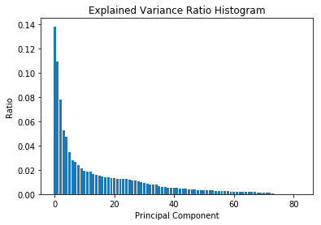

```python
plt.bar(range(0, len(pcaObject.explained_variance_ratio_)), pcaObject.explained_variance_ratio_)
plt.title('Explained Variance Ratio Histogram')
plt.xlabel('Principal Component')
plt.ylabel('Ratio')
plt.show()
```

[figure not shown]

```python
# Investigate the variance accounted for by each principal component.
plt.figure(figsize = (9,6))
plt.plot(range(len(pcaObject.explained_variance_ratio_)),
         np.cumsum(pcaObject.explained_variance_ratio_),
         linewidth=2.0, label = 'Explained Variance Ratio')
plt.bar(range(0, len(pcaObject.explained_variance_ratio_)),
        pcaObject.explained_variance_ratio_, color ='black', label ='Cumulative Explained Variance')

plt.title("Cumulative Variance Explained")
plt.xlabel("# Components")
plt.legend(loc = 'upper left')
plt.ylabel("Ratio of Variance explained")
plt.show()
```

#### PCA w/10 Principal Components

```python
# Re-apply PCA to the data while selecting for number of components to retain.
azdias_PCAObject_10 = PCA(n_components = 10)
azdias_PCAObject_10.fit_transform(azdiasFinal_df)
```

```
array([[ 1.36440361, -3.15230874, -3.22989169, ..., -0.47976801,
        -0.99390223, -0.31592781],
       [ 3.36099992, -2.67026574, -1.39571912, ..., -0.26308286,
         1.66323811,  0.29741274],
       [-0.42213038,  0.03721343, -2.70630073, ...,  0.78367594,
         1.51798677, -0.43358956],
       ...,
       [-0.73074155, -3.25100293, -1.25732452, ...,  0.67887803,
         1.27129653, -1.62817112],
       [ 5.36552962, -2.69397015,  3.64255004, ..., -2.06399903,
         2.34307826, -3.31679509],
       [-0.7766095 ,  2.10296803,  2.78428068, ..., -0.5195377 ,
         1.06120577, -0.6031636 ]])
```

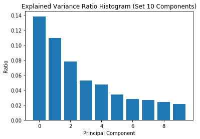

```python
plt.bar(range(0, len(azdias_PCAObject_10.explained_variance_ratio_)), azdias_PCAObject_10.explained_variance_ratio_)
plt.title('Explained Variance Ratio Histogram (Set 10 Components)')
plt.xlabel('Principal Component')
plt.ylabel('Ratio')
plt.show()
```

[figure not shown]

```python
# Investigate the variance accounted for by each principal component.
plt.figure(figsize = (9,6))
plt.plot(range(len(azdias_PCAObject_10.explained_variance_ratio_)),
         np.cumsum(azdias_PCAObject_10.explained_variance_ratio_),
         linewidth=2.0, label = 'Explained Variance Ratio')
plt.bar(range(0, len(azdias_PCAObject_10.explained_variance_ratio_)),
        azdias_PCAObject_10.explained_variance_ratio_, color ='black', label ='Cumulative Explained Variance')

plt.title("Cumulative Variance Explained (Set 10 Components)")
plt.xlabel("# Components")
plt.legend(loc = 'upper left')
plt.ylabel("Ratio of Variance explained")
plt.show()
```

#### PCA w/40 Principal Components

```python
# Re-apply PCA to the data while selecting for number of components to retain.
azdiasPCAObject_40 = PCA(n_components = 40)
azdias_FinalPCA_40_Df = azdiasPCAObject_40.fit_transform(azdiasFinal_df)
```

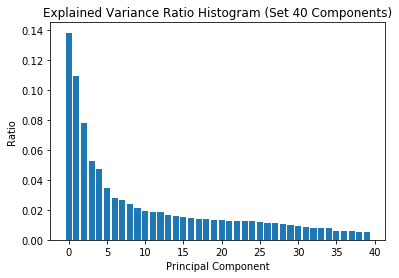

```python
plt.bar(range(0, len(azdiasPCAObject_40.explained_variance_ratio_)), azdiasPCAObject_40.explained_variance_ratio_)
plt.title('Explained Variance Ratio Histogram (Set 40 Components)')
plt.xlabel('Principal Component')
plt.ylabel('Ratio')
plt.show()
```

[figure not shown]

```python
# Investigate the variance accounted for by each principal component.
plt.figure(figsize = (9,6))
plt.plot(range(len(azdiasPCAObject_40.explained_variance_ratio_)),
         np.cumsum(azdiasPCAObject_40.explained_variance_ratio_),
         linewidth=2.0, label = 'Explained Variance Ratio')
plt.bar(range(0, len(azdiasPCAObject_40.explained_variance_ratio_)),
        azdiasPCAObject_40.explained_variance_ratio_, color ='black', label ='Cumulative Explained Variance')

plt.title("Cumulative Variance Explained (Set 40 Components)")
plt.xlabel("# Components")
plt.legend(loc = 'upper left')
plt.ylabel("Ratio of Variance explained")
plt.show()
```

### Discussion 2.2: Perform Dimensionality Reduction

#### Ans:

- The initial defaults for PCA had most, to all, components in the implementation. This implementation has a cummulative ratio of variance explained to 1.00.
  - So, this would mean that the more coverage of principal components would need to reach a attainable explained variance for PCA implementation. It would be more ideal to have less principal components to reach more coverage of explained ratio of variance.

So, we attempt to find the right number of components to meet the satisfaction of ratio of variance explained, but meanwhile...not including more principal components, for technical reasons.

- We made a re-attempt to create a PCA implementation with 10 principal components. However, the cumulative Ratio of Variance Explained reached ~0.50. However, that is not as sufficent we need to approach a more suitable value.
- Finally, we set the number of principal components to 40 for a PCA model. In this implementation, we observed that the cumulative ratio of variance explained reaches closer to 1.00. This value was near an estimated ~.90. Again, this is with 40 principal components.

Therefore, we proceed with the `40 principal components` PCA model.

### Step 2.3: Interpret Principal Components

Now that we have our transformed principal components, it's a nice idea to check out the weight of each variable on the first few components to see if they can be interpreted in some fashion.

As a reminder, each principal component is a unit vector that points in the direction of highest variance (after accounting for the variance captured by earlier principal components). The further a weight is from zero, the more the principal component is in the direction of the corresponding feature. If two features have large weights of the same sign (both positive or both negative), then increases in one tend expect to be associated with increases in the other. To contrast, features with different signs can be expected to show a negative correlation: increases in one variable should result in a decrease in the other.

- To investigate the features, you should map each weight to their corresponding feature name, then sort the features according to weight. The most interesting features for each principal component, then, will be those at the beginning and end of the sorted list. Use the data dictionary document to help you understand these most prominent features, their relationships, and what a positive or negative value on the principal component might indicate.
- You should investigate and interpret feature associations from the first three principal components in this substep. To help facilitate this, you should write a function that you can call at any time to print the sorted list of feature weights, for the *i*-th principal component. This might come in handy in the next step of the project, when you interpret the tendencies of the discovered clusters.

```python
# Map weights for the first principal component to corresponding feature names
# and then print the linked values, sorted by weight.
# HINT: Try defining a function here or in a new cell that you can reuse in the
# other cells.
azdiasPCAObject_40.explained_variance_ratio_
```

```
array([ 0.13849989,  0.1094339 ,  0.0783518 ,  0.05254222,  0.04745532,
        0.03431148,  0.02824988,  0.02638048,  0.02368854,  0.02149313,
        0.01904889,  0.01884203,  0.01825906,  0.01640427,  0.0158553 ,
        0.01529573,  0.01469578,  0.01414421,  0.0137784 ,  0.01338891,
        0.01307442,  0.01283994,  0.01257458,  0.0123601 ,  0.01235493,
        0.01196598,  0.01132393,  0.01118592,  0.01048125,  0.00989626,
        0.00920441,  0.00877913,  0.00818753,  0.00778691,  0.00768407,
        0.00620567,  0.00593779,  0.00586603,  0.00539787,  0.00526636])
```

```python
# Map weights for the second principal component to corresponding feature names
# and then print the linked values, sorted by weight.
azdias_componentWeightsMappings = pd.DataFrame(np.round(azdiasPCAObject_40.components_, 2),
                                               columns = azdiasFinal_df.columns)

secondPrincipalComponent = 1 # (This is the 2nd component)
azdias_componentWeightsMap2ndComp = azdias_componentWeightsMappings.iloc[secondPrincipalComponent]

# First 20 values for the 2nd Principal Component, using PCA model w/40 components
azdias_componentWeightsMap2ndComp.sort_values(ascending=False)[:20]
```

```
ALTERSKATEGORIE_GROB             0.25
FINANZ_VORSORGER                 0.23
SEMIO_ERL                        0.21
RETOURTYP_BK_S                   0.16
SEMIO_LUST                       0.16
PRAEGENDE_JUGENDJAHRE_ERA_60s    0.13
PRAEGENDE_JUGENDJAHRE_ERA_50s    0.12
W_KEIT_KIND_HH                   0.12
PLZ8_BAUMAX                      0.11
FINANZ_HAUSBAUER                 0.10
SHOPPER_TYP_3.0                  0.10
KBA05_ANTG4                      0.09
ORTSGR_KLS9                      0.09
HH_EINKOMMEN_SCORE               0.09
EWDICHTE                         0.09
FINANZ_MINIMALIST                0.08
PRAEGENDE_JUGENDJAHRE_ERA_70s    0.08
PLZ8_ANTG3                       0.07
PLZ8_ANTG4                       0.07
ANZ_HAUSHALTE_AKTIV              0.07
Name: 1, dtype: float64
```

```python
component1_top3_bottom3 = pd.DataFrame(pd.concat([azdias_componentWeightsMap2ndComp.sort_values(ascending=False)[:3],
azdias_componentWeightsMap2ndComp.sort_values(ascending=False)[-3:]], axis=0))
```

```python
component1_top3_bottom3.columns = ['Component']
```

```python
component1_top3_bottom3
```

|  | Component |
| --- | --- |
| ALTERSKATEGORIE_GROB | 0.25 |
| FINANZ_VORSORGER | 0.23 |
| SEMIO_ERL | 0.21 |
| FINANZ_UNAUFFAELLIGER | -0.25 |
| SEMIO_REL | -0.25 |
| FINANZ_SPARER | -0.25 |

```python
# Map weights for the third principal component to corresponding feature names
# and then print the linked values, sorted by weight.


thirdPrincipalComponent = 2 # (This is the 3nd component)
azdias_componentWeightsMap3rdComp = azdias_componentWeightsMappings.iloc[thirdPrincipalComponent]

# First 20 values for the 2nd Principal Component, using PCA model w/40 components
azdias_componentWeightsMap3rdComp.sort_values(ascending=False)[:20]
```

```
SEMIO_VERT                                     0.34
SEMIO_KULT                                     0.31
SEMIO_SOZ                                      0.30
SEMIO_FAM                                      0.22
SHOPPER_TYP_1.0                                0.10
FINANZ_MINIMALIST                              0.08
OST_WEST_KZ_LOCATION_West                      0.08
SEMIO_MAT                                      0.08
SEMIO_REL                                      0.07
PLZ8_BAUMAX                                    0.07
PRAEGENDE_JUGENDJAHRE_MAINSTREAM_Mainstream    0.07
HH_EINKOMMEN_SCORE                             0.06
PRAEGENDE_JUGENDJAHRE_ERA_80s                  0.05
SEMIO_TRADV                                    0.05
PRAEGENDE_JUGENDJAHRE_MAINSTREAM_Avantgarde    0.05
GEBAEUDETYP_3.0                                0.05
GREEN_AVANTGARDE                               0.05
KBA05_ANTG4                                    0.04
KBA05_ANTG3                                    0.04
ANZ_PERSONEN                                   0.04
Name: 2, dtype: float64
```

```python
component2_top3_bottom3 = pd.DataFrame(pd.concat([azdias_componentWeightsMap3rdComp.sort_values(ascending=False)[:3],
azdias_componentWeightsMap3rdComp.sort_values(ascending=False)[-3:]], axis=0))
component2_top3_bottom3.columns = ['Components']
```

```python
component2_top3_bottom3
```

|  | Components |
| --- | --- |
| SEMIO_VERT | 0.34 |
| SEMIO_KULT | 0.31 |
| SEMIO_SOZ | 0.30 |
| SEMIO_KRIT | -0.31 |
| ANREDE_KZ | -0.32 |
| SEMIO_KAEM | -0.34 |

### Discussion 2.3: Interpret Principal Components

Investigate the first few principal components generated. Can we interpret positive and negative values from them in a meaningful way?

#### Ans:

The first few principal components are created for explanining the general variability for a subset of features that explain an original dataset. Moreover, these principal components are Eigenvectors representing a direction w/variability.

That being said, these Principal Components (Eigenvalues) represent magnitude, or importance between inputted features. And this can also serve to showing correlation of important features, in a positive or negative direction.

```python
component1_top3_bottom3
```

|  | Component |
| --- | --- |
| ALTERSKATEGORIE_GROB | 0.25 |
| FINANZ_VORSORGER | 0.23 |
| SEMIO_ERL | 0.21 |
| FINANZ_UNAUFFAELLIGER | -0.25 |
| SEMIO_REL | -0.25 |
| FINANZ_SPARER | -0.25 |

For the first feature with most explained variability `ALTERSKATEGORIE_GROB`, we find `FINANZ_VORSORGER` and `SEMIO_ERL` having a positive correlation with it.

> This is saying that a higher Age Topology from `ALTERSKATEGORIE_GROB` will have a positive assocation with higher financial income (`FINANZ_VORSORGER`) and personality affinity (`SEMIO_ERL`)

However, `ALTERSKATEGORIE_GROB` has a negative correlation with `SEMIO_REL` & `FINANZ_SPARER`

```python
component2_top3_bottom3
```

|  | Components |
| --- | --- |
| SEMIO_VERT | 0.34 |
| SEMIO_KULT | 0.31 |
| SEMIO_SOZ | 0.30 |
| SEMIO_KRIT | -0.31 |
| ANREDE_KZ | -0.32 |
| SEMIO_KAEM | -0.34 |

For the first feature with most explained variability `SEMIO_VERT`, we find `SEMIO_SOZ` and `SEMIO_KULT` having a positive correlation with it.

> This is saying that a low Personality Affinity from `SEMIO_VERT` will have a positive assocation with other low (`SEMIO_SOZ`) and (`SEMIO_KULT`) personality affinities.

## Step 3: Clustering

### Step 3.1: Apply Clustering to General Population

You've assessed and cleaned the demographics data, then scaled and transformed them. Now, it's time to see how the data clusters in the principal components space. In this substep, you will apply k-means clustering to the dataset and use the average within-cluster distances from each point to their assigned cluster's centroid to decide on a number of clusters to keep.

- Use sklearn's KMeans class to perform k-means clustering on the PCA-transformed data.
- Then, compute the average difference from each point to its assigned cluster's center. **Hint**: The KMeans object's `.score()` method might be useful here, but note that in sklearn, scores tend to be defined so that larger is better. Try applying it to a small, toy dataset, or use an internet search to help your understanding.
- Perform the above two steps for a number of different cluster counts. You can then see how the average distance decreases with an increasing number of clusters. However, each additional cluster provides a smaller net benefit. Use this fact to select a final number of clusters in which to group the data. **Warning**: because of the large size of the dataset, it can take a long time for the algorithm to resolve. The more clusters to fit, the longer the algorithm will take. You should test for cluster counts through at least 10 clusters to get the full picture, but you shouldn't need to test for a number of clusters above about 30.
- Once you've selected a final number of clusters to use, re-fit a KMeans instance to perform the clustering operation. Make sure that you also obtain the cluster assignments for the general demographics data, since you'll be using them in the final Step 3.3.

```python
from sklearn.cluster import KMeans
```

```python
# Over a number of different cluster counts...
kMeansClusters = 10
kMeansScoresList = []
for k in range(1,kMeansClusters):

    # run k-means clustering on the data and...
    kmeansObject = KMeans(n_clusters = k)
    model = kmeansObject.fit(azdias_FinalPCA_40_Df) # 40 Principal Component object for azdias

    # compute the average within-cluster distances.
    kMeansScore = np.abs(model.score(azdias_FinalPCA_40_Df))
    kMeansScoresList.append(kMeansScore)
    print(k)
```

```
1
2
3
4
5
6
7
8
9
```

```python
kMeansScoresList
```

```
[65583061.536493085,
 58381822.154890418,
 53759150.407269955,
 50542811.320413873,
 48191822.304235324,
 46585018.81523177,
 45190262.332370371,
 43932203.001839422,
 43072141.435869932]
```

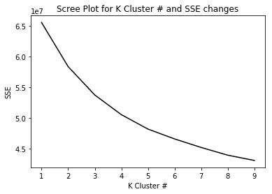

```python
# Investigate the change in within-cluster distance across number of clusters.
# HINT: Use matplotlib's plot function to visualize this relationship.

plt.plot(range(1,kMeansClusters), kMeansScoresList, 'black')
plt.xlabel('K Cluster #')
plt.title('Scree Plot for K Cluster # and SSE changes')
plt.ylabel('SSE')
plt.show()
```

```python
# Re-fit the k-means model with the selected number of clusters and obtain
# cluster predictions for the general population demographics data.
clusterVal = 6
kMeansObject_final = KMeans(n_clusters = clusterVal)
kMeans_modelFinal = kMeansObject_final.fit(azdias_FinalPCA_40_Df)
```

```python
azdias_FinalPrediction = kMeansObject_final.predict(azdias_FinalPCA_40_Df)
```

### Discussion 3.1: Apply Clustering to General Population

#### Ans:

> Recall, having a good SSE is ideal, but also considering the processing time for the implementation on the data is something to consider as well.

### Step 3.2: Apply All Steps to the Customer Data

Now that you have clusters and cluster centers for the general population, it's time to see how the customer data maps on to those clusters. Take care to not confuse this for re-fitting all of the models to the customer data. Instead, you're going to use the fits from the general population to clean, transform, and cluster the customer data. In the last step of the project, you will interpret how the general population fits apply to the customer data.

- Don't forget when loading in the customers data, that it is semicolon (`;`) delimited.
- Apply the same feature wrangling, selection, and engineering steps to the customer demographics using the `clean_data()` function you created earlier. (You can assume that the customer demographics data has similar meaning behind missing data patterns as the general demographics data.)
- Use the sklearn objects from the general demographics data, and apply their transformations to the customers data. That is, you should not be using a `.fit()` or `.fit_transform()` method to re-fit the old objects, nor should you be creating new sklearn objects! Carry the data through the feature scaling, PCA, and clustering steps, obtaining cluster assignments for all of the data in the customer demographics data.

```python
# Load in the customer demographics data.
customer_df = pd.read_csv('Udacity_CUSTOMERS_Subset.csv', sep = ";")
```

```python
# Apply preprocessing, feature transformation, and clustering from the general
# demographics onto the customer data, obtaining cluster predictions for the
# customer demographics data.
customerTransformedDf = clean_data(customer_df, feat_info, 30)

imputer = Imputer(missing_values='NaN', strategy = 'median')
```

```python
customerTransformedImputeDf = pd.DataFrame(imputer.fit_transform(customerTransformedDf))
customerTransformedImputeDf.columns = customerTransformedDf.columns
```

```python
customerTransformedImputeDf.head()
```

|  | ALTERSKATEGORIE_GROB | ANREDE_KZ | FINANZ_MINIMALIST | FINANZ_SPARER | FINANZ_VORSORGER | FINANZ_ANLEGER | FINANZ_UNAUFFAELLIGER | FINANZ_HAUSBAUER | GREEN_AVANTGARDE | HEALTH_TYP | ... | PRAEGENDE_JUGENDJAHRE_ERA_ | PRAEGENDE_JUGENDJAHRE_ERA_40s | PRAEGENDE_JUGENDJAHRE_ERA_50s | PRAEGENDE_JUGENDJAHRE_ERA_60s | PRAEGENDE_JUGENDJAHRE_ERA_70s | PRAEGENDE_JUGENDJAHRE_ERA_80s | PRAEGENDE_JUGENDJAHRE_MAINSTREAM_Avantgarde | PRAEGENDE_JUGENDJAHRE_MAINSTREAM_Mainstream | CAMEO_INTL_2015_CLASS_TYPE_NA | CAMEO_INTL_2015_FAMILY_NA |
| --- | --- | --- | --- | --- | --- | --- | --- | --- | --- | --- | --- | --- | --- | --- | --- | --- | --- | --- | --- | --- | --- |
| 0 | 4.0 | 0.0 | 5.0 | 1.0 | 5.0 | 1.0 | 2.0 | 2.0 | 1.0 | 1.0 | ... | 0.0 | 0.0 | 1.0 | 0.0 | 0.0 | 0.0 | 1.0 | 0.0 | 1.0 | 1.0 |
| 1 | 4.0 | 0.0 | 5.0 | 1.0 | 5.0 | 1.0 | 3.0 | 2.0 | 0.0 | 1.0 | ... | 1.0 | 0.0 | 0.0 | 0.0 | 0.0 | 0.0 | 0.0 | 0.0 | 1.0 | 1.0 |
| 2 | 4.0 | 1.0 | 5.0 | 1.0 | 5.0 | 1.0 | 4.0 | 4.0 | 1.0 | 2.0 | ... | 0.0 | 0.0 | 1.0 | 0.0 | 0.0 | 0.0 | 1.0 | 0.0 | 1.0 | 1.0 |
| 3 | 4.0 | 0.0 | 5.0 | 1.0 | 5.0 | 2.0 | 1.0 | 2.0 | 0.0 | 2.0 | ... | 0.0 | 1.0 | 0.0 | 0.0 | 0.0 | 0.0 | 0.0 | 1.0 | 1.0 | 1.0 |
| 4 | 3.0 | 0.0 | 3.0 | 1.0 | 4.0 | 4.0 | 5.0 | 2.0 | 0.0 | 3.0 | ... | 0.0 | 0.0 | 0.0 | 0.0 | 1.0 | 0.0 | 0.0 | 1.0 | 1.0 | 1.0 |

5 rows × 83 columns

```python
# Identify if customer & general features are different after transformations.
# This difference observed is if any columns are missing between the two datasets.

def Diff(list1, list2):
    differenceLists = list(set(list1) - set(list2))
    return(differenceLists)

print(Diff(azdiasFinal_df.columns.tolist(), customerTransformedImputeDf.columns.tolist()))
```

```
[]
```

```python
customerPreFinal = standardScalerObject.transform(customerTransformedImputeDf)

columnNamesFinal = customerTransformedImputeDf.columns.tolist()
customerFinal_df = pd.DataFrame(customerPreFinal, columns= columnNamesFinal )

customer_FinalPCA_40_Df = azdiasPCAObject_40.transform(customerFinal_df)
```

```python
customer_FinalPrediction = kMeansObject_final.predict(customer_FinalPCA_40_Df)
```